# CASE STUDY W01

Payton Stastny

April 23, 2022

```r
# Use this R-Chunk to import all your datasets!
```

```r
# Use this R-Chunk to clean & wrangle your data!
```

## Data Visualization

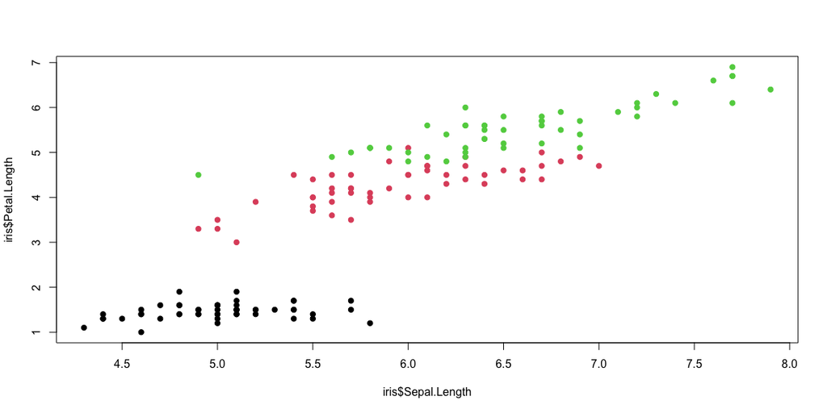

```r
# Use this R-Chunk to plot & visualize your data!
plot(x = iris$Sepal.Length,
     y = iris$Petal.Length,
     col = iris$Species, pch = 19)
```

## Article 1

https://pudding.cool/2022/02/redraft/

This had some extremely good visualizations. It especially did a good job where you can choose a team and see what could have been senarios for players you could have drafted. it is not so fun though, to look at what your own team could have been because then you will be depressed seeing what they missed. but overall it was a great visualization.

Something that could have been better was the busts and steals of every draft class, it wasnt very sself explanitory and took a lot more thought into figuring out what it meant. It wasnt clear on what was being displayed but after a while i understood what they were trying to do, it wasnt executed well.

## Article 2

https://pudding.cool/2020/01/diaspora/

This visualization is interesting. The use of the data and creating a map that showed where most immigrants live in the US was really good. The ability to pick a country and then the map zooms in on the area where the immigrants are more populated.

One thing that was not very good about the visualization is that there was no data. It just showed me where people were rather than telling me how many people live in that area. There wasnt any data to give me.

## Article 3

https://pudding.cool/2019/03/hype/

This article had some great visualizations. The animation of it at first was really good. The use of color saturation to go along with the dots was really well done. The graph with the ranked and unranked players through all the levels of basketball was very well put.

The only thing that would make this visualization better would be to make the names a little bigger when hovering over a dot. and maybe make it quicker to understand that the dots are the top 100 ranked players shown from left to right.